# Topic modelling on ds spooky authors

## Description of the problem

The problem to be solved in this natural language processing project is to discover possible abstract themes that occur in a collection of documents. Topic modeling is a very useful tool when trying to discover hidden semantic structures in texts. The dataset to be used contains excerpts from horror novels by authors Edgar Allan Poe (EAP), Mary Shelley (MWS), and HP Lovecraft (HPL). This dataset comes from a competition in 2017 on the popular Kaggle web community, it can be found at the following web URL: https://www.kaggle.com/c/spooky-author-identification

In this competition, participants were asked to build a model that was capable of predicting the author of a specific document, also to share new knowledge about the data.

## Load libraries

```r
library(tm)
library(ggplot2)
library(reshape2)
library(wordcloud)
library(RWeka)

library(tidytext) # tidy implimentation of NLP methods
library(tidyverse) # general utility & workflow functions

# Lemmatization
library(textstem)

# LDA (topic modelling)
library(topicmodels)
```

## Load Files

```r
# Reading the data
df <- read.csv("data/train.csv")
head(df)
```

|  | id | text | author |
| --- | --- | --- | --- |
| 1 | id26305 | This process, however, afforded me no means of ascertaining the dimensions of my dungeon; as I might make its circuit, and return to the point whence I set out, without being aware of the fact; so per… | EAP |
| 2 | id17569 | It never once occurred to me that the fumbling might be a mere mistake. | HPL |
| 3 | id11008 | In his left hand was a gold snuff box, from which, as he capered down the hill, cutting all manner of fantastic steps, he took snuff incessantly with an air of the greatest possible self satisfaction. | EAP |
| 4 | id27763 | How lovely is spring As we looked from Windsor Terrace on the sixteen fertile counties spread beneath, speckled by happy cottages and wealthier towns, all looked as in former years, heart cheering and… | MWS |
| 5 | id12958 | Finding nothing else, not even gold, the Superintendent abandoned his attempts; but a perplexed look occasionally steals over his countenance as he sits thinking at his desk. | HPL |
| 6 | id22965 | A youth passed in solitude, my best years spent under your gentle and feminine fosterage, has so refined the groundwork of my character that I cannot overcome an intense distaste to the usual brutalit… | MWS |

## Corpus

Transforming the data frame in to corpus format.

```r
# Rename id column to "doc_id"
names(df)[1] <- "doc_id"

# Convert to corpus
corpus <- Corpus(DataframeSource(df))
```

Check the length of the corpus.

```r
length(corpus)
```

```
[1] 19579
```

Inspecting the first entry.

```r
inspect(corpus[[1]])
```

```
<<PlainTextDocument>>
Metadata:  7
Content:  chars: 231

This process, however, afforded me no means of ascertaining the dimensions of my dungeon; as I might make its circuit, and return to the point whence I set out, without being aware of the fact; so perfectly uniform seemed the wall.
```

Checking the metadata of the first entry.

```r
meta(corpus[[1]])
```

```
  author       : character(0)
  datetimestamp: 2021-01-12 21:23:47
  description  : character(0)
  heading      : character(0)
  id           : id26305
  language     : en
  origin       : character(0)
```

## Text cleaning

Print some instances to check the data.

```r
inspect(corpus[1:5])
```

```
<<SimpleCorpus>>
Metadata:  corpus specific: 1, document level (indexed): 1
Content:  documents: 5

                                                                                                                                                                                                                                id26305
This process, however, afforded me no means of ascertaining the dimensions of my dungeon; as I might make its circuit, and return to the point whence I set out, without being aware of the fact; so perfectly uniform seemed the wall.
                                                                                                                                                                                                                                id17569
                                                                                                                                                                It never once occurred to me that the fumbling might be a mere mistake.
                                                                                                                                                                                                                                id11008
                               In his left hand was a gold snuff box, from which, as he capered down the hill, cutting all manner of fantastic steps, he took snuff incessantly with an air of the greatest possible self satisfaction.
                                                                                                                                                                                                                                id27763
                         How lovely is spring As we looked from Windsor Terrace on the sixteen fertile counties spread beneath, speckled by happy cottages and wealthier towns, all looked as in former years, heart cheering and fair.
                                                                                                                                                                                                                                id12958
                                                         Finding nothing else, not even gold, the Superintendent abandoned his attempts; but a perplexed look occasionally steals over his countenance as he sits thinking at his desk.
```

Check the possible transformations on the corpus.

```r
getTransformations()
```

```
[1] "removeNumbers"     "removePunctuation" "removeWords"       "stemDocument"      "stripWhitespace"
```

Remove punctuation signs of the corpus.

```r
corpus <- tm_map(corpus, removePunctuation)
inspect(corpus[1:5])
```

```
<<SimpleCorpus>>
Metadata:  corpus specific: 1, document level (indexed): 1
Content:  documents: 5

                                                                                                                                                                                                                         id26305
This process however afforded me no means of ascertaining the dimensions of my dungeon as I might make its circuit and return to the point whence I set out without being aware of the fact so perfectly uniform seemed the wall
                                                                                                                                                                                                                         id17569
                                                                                                                                                          It never once occurred to me that the fumbling might be a mere mistake
                                                                                                                                                                                                                         id11008
                             In his left hand was a gold snuff box from which as he capered down the hill cutting all manner of fantastic steps he took snuff incessantly with an air of the greatest possible self satisfaction
                                                                                                                                                                                                                         id27763
                      How lovely is spring As we looked from Windsor Terrace on the sixteen fertile counties spread beneath speckled by happy cottages and wealthier towns all looked as in former years heart cheering and fair
                                                                                                                                                                                                                         id12958
                                                      Finding nothing else not even gold the Superintendent abandoned his attempts but a perplexed look occasionally steals over his countenance as he sits thinking at his desk
```

Set all the characters to lower case.

```r
corpus <- tm_map(corpus, content_transformer(tolower))
inspect(corpus[1:5])
```

```
<<SimpleCorpus>>
Metadata:  corpus specific: 1, document level (indexed): 1
Content:  documents: 5

                                                                                                                                                                                                                         id26305
this process however afforded me no means of ascertaining the dimensions of my dungeon as i might make its circuit and return to the point whence i set out without being aware of the fact so perfectly uniform seemed the wall
                                                                                                                                                                                                                         id17569
                                                                                                                                                          it never once occurred to me that the fumbling might be a mere mistake
                                                                                                                                                                                                                         id11008
                             in his left hand was a gold snuff box from which as he capered down the hill cutting all manner of fantastic steps he took snuff incessantly with an air of the greatest possible self satisfaction
                                                                                                                                                                                                                         id27763
                      how lovely is spring as we looked from windsor terrace on the sixteen fertile counties spread beneath speckled by happy cottages and wealthier towns all looked as in former years heart cheering and fair
                                                                                                                                                                                                                         id12958
                                                      finding nothing else not even gold the superintendent abandoned his attempts but a perplexed look occasionally steals over his countenance as he sits thinking at his desk
```

Stemming  
Converts all variants of a term to the same term, an example: the terms: running, runner, ran are converted to run after stemming the document. Stemming algorithms work by cutting off the end or the beginning of the word.

```r
corpus_temp <- tm_map(corpus, stemDocument)
inspect(corpus_temp[1:5])
```

```
<<SimpleCorpus>>
Metadata:  corpus specific: 1, document level (indexed): 1
Content:  documents: 5

                                                                                                                                                                                                   id26305
this process howev afford me no mean of ascertain the dimens of my dungeon as i might make it circuit and return to the point whenc i set out without be awar of the fact so perfect uniform seem the wall
                                                                                                                                                                                                   id17569
                                                                                                                                            it never onc occur to me that the fumbl might be a mere mistak
                                                                                                                                                                                                   id11008
                         in his left hand was a gold snuff box from which as he caper down the hill cut all manner of fantast step he took snuff incess with an air of the greatest possibl self satisfact
                                                                                                                                                                                                   id27763
                   how love is spring as we look from windsor terrac on the sixteen fertil counti spread beneath speckl by happi cottag and wealthier town all look as in former year heart cheer and fair
                                                                                                                                                                                                   id12958
                                                            find noth els not even gold the superintend abandon his attempt but a perplex look occasion steal over his counten as he sit think at his desk
```

We are not going to apply stemming, instead we are going to use lemmatization.

The main difference is that lemmatization considers the morphological analysis of the words.

```r
corpus <- tm_map(corpus, lemmatize_strings)
inspect(corpus[1:5])
```

```
<<SimpleCorpus>>
Metadata:  corpus specific: 1, document level (indexed): 1
Content:  documents: 5

                                                                                                                                                                                                           id26305
this process however afford me no mean of ascertain the dimension of my dungeon as i may make its circuit and return to the point whence i set out without be aware of the fact so perfectly uniform seem the wall
                                                                                                                                                                                                           id17569
                                                                                                                                                   it never once occur to me that the fumble may be a mere mistake
                                                                                                                                                                                                           id11008
                          in his leave hand be a gold snuff box from which as he caper down the hill cut all manner of fantastic step he take snuff incessantly with a air of the great possible self satisfaction
                                                                                                                                                                                                           id27763
                       how lovely be spring as we look from windsor terrace on the sixteen fertile county spread beneath speckle by happy cottage and wealthy town all look as in former year heart cheer and fair
                                                                                                                                                                                                           id12958
                                                     find nothing else not even gold the superintendent abandon his attempt but a perplex look occasionally steal over his countenance as he sit think at his desk
```

Remove numbers even though in the firsts instances we did not found any number.

```r
corpus <- tm_map(corpus, removeNumbers)
```

Remove the extra whitespaces.

```r
corpus <- tm_map(corpus, stripWhitespace)
```

## Stop Words removal

Stop words are those words which appear the most in any language. They usually are words without any meaning by themselves, lets check the stopwords.

```r
stopwords()
```

```
  [1] "i"          "me"         "my"         "myself"     "we"         "our"        "ours"       "ourselves"
  [9] "you"        "your"       "yours"      "yourself"   "yourselves" "he"         "him"        "his"
 [17] "himself"    "she"        "her"        "hers"       "herself"    "it"         "its"        "itself"
 [25] "they"       "them"       "their"      "theirs"     "themselves" "what"       "which"      "who"
 [33] "whom"       "this"       "that"       "these"      "those"      "am"         "is"         "are"
 [41] "was"        "were"       "be"         "been"       "being"      "have"       "has"        "had"
 [49] "having"     "do"         "does"       "did"        "doing"      "would"      "should"     "could"
 [57] "ought"      "i'm"        "you're"     "he's"       "she's"      "it's"       "we're"      "they're"
 [65] "i've"       "you've"     "we've"      "they've"    "i'd"        "you'd"      "he'd"       "she'd"
 [73] "we'd"       "they'd"     "i'll"       "you'll"     "he'll"      "she'll"     "we'll"      "they'll"
 [81] "isn't"      "aren't"     "wasn't"     "weren't"    "hasn't"     "haven't"    "hadn't"     "doesn't"
 [89] "don't"      "didn't"     "won't"      "wouldn't"   "shan't"     "shouldn't"  "can't"      "cannot"
 [97] "couldn't"   "mustn't"    "let's"      "that's"     "who's"      "what's"     "here's"     "there's"
[105] "when's"     "where's"    "why's"      "how's"      "a"          "an"         "the"        "and"
[113] "but"        "if"         "or"         "because"    "as"         "until"      "while"      "of"
[121] "at"         "by"         "for"        "with"       "about"      "against"    "between"    "into"
[129] "through"    "during"     "before"     "after"      "above"      "below"      "to"         "from"
[137] "up"         "down"       "in"         "out"        "on"         "off"        "over"       "under"
[145] "again"      "further"    "then"       "once"       "here"       "there"      "when"       "where"
[153] "why"        "how"        "all"        "any"        "both"       "each"       "few"        "more"
[161] "most"       "other"      "some"       "such"       "no"         "nor"        "not"        "only"
[169] "own"        "same"       "so"         "than"       "too"        "very"
```

Remove stopwords

```r
inspect(corpus[[1]])
```

```
<<PlainTextDocument>>
Metadata:  7
Content:  chars: 210

this process however afford me no mean of ascertain the dimension of my dungeon as i may make its circuit and return to the point whence i set out without be aware of the fact so perfectly uniform seem the wall
```

```r
corpus = tm_map(corpus,removeWords,stopwords())
inspect(corpus[[1]])
```

```
<<PlainTextDocument>>
Metadata:  7
Content:  chars: 163

 process however afford   mean  ascertain  dimension   dungeon   may make  circuit  return   point whence  set  without  aware   fact  perfectly uniform seem  wall
```

## Common words

Apart from the stopwords of the tdm package we can also identify the terms that are repeated the most and delete them from the corpus since they probably do not provide any new knowledge.

```r
tdm = TermDocumentMatrix(corpus)
tdm
```

```
<<TermDocumentMatrix (terms: 18007, documents: 19579)>>
Non-/sparse entries: 248563/352310490
Sparsity           : 100%
Maximal term length: 19
Weighting          : term frequency (tf)
```

After all the transformations, lets check how many terms have been identified in the TDM

```r
length(dimnames(tdm)$Terms)
```

```
[1] 18007
```

Which terms are the most frequent and which are the least.

```r
fr=rowSums(as.matrix(tdm))
common_words <- tail(sort(fr),20)
common_words
```

```
   eye    day little   even   find   know   time   come   will   make   good    may    man    now    say    see
   732    743    781    823    843    861    872    886    947    960   1028   1071   1134   1170   1221   1239
  upon    one    can   much
  1411   1676   1741   2261
```

```r
# delete some terms from the most common words
common_words <- common_words[names(common_words) %in% c("man", "time", "day", "eye") == FALSE]
```

Check which terms only appears once

```r
sum(fr == 1)
```

```
[1] 6584
```

6584 of the 18007 terms only appears once.

Remove the new stop words (common words)

```r
new_stop_words <- names(common_words)
corpus = tm_map(corpus,removeWords,new_stop_words)
# Term document matrix with all the previous transformation
tdm = TermDocumentMatrix(corpus)
```

## Explore the data

How many instances belong to what authors.

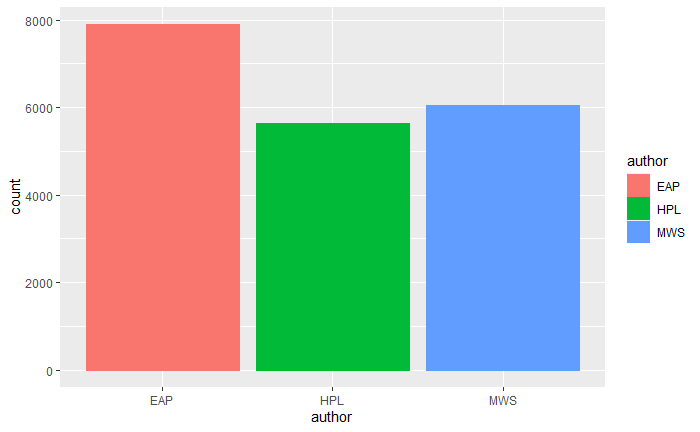

```r
ggplot(df, aes(x=author, color=author, fill=author)) +
  geom_bar()
```

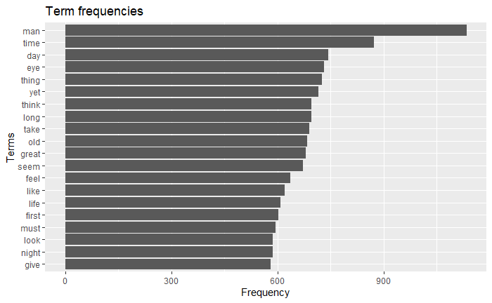

```r
tdm = TermDocumentMatrix(corpus)
fr=rowSums(as.matrix(tdm))

high.fr=tail(sort(fr),n=20)
hfp.df=as.data.frame(sort(high.fr))
hfp.df$names <- rownames(hfp.df)

ggplot(hfp.df, aes(reorder(names,high.fr), high.fr)) +
  geom_bar(stat="identity") + coord_flip() +
  xlab("Terms") + ylab("Frequency") +
  ggtitle("Term frequencies")
```

### Check common words of each author

Set the colours to be used in wordclouds

```r
pal <- brewer.pal(9, "BuGn")
pal <- pal[-(1:2)]

set.seed(1234)
```

#### EAP

Edgar Allen Poe

```r
# Make transformations
corpus.EAP = VCorpus(DataframeSource(df[df$author == "EAP",]))
corpus.EAP = tm_map(corpus.EAP, content_transformer(tolower))
corpus.EAP = tm_map(corpus.EAP, removeWords, c(stopwords(),new_stop_words))
corpus.EAP = tm_map(corpus.EAP, removePunctuation)
corpus.EAP = tm_map(corpus.EAP, removeNumbers)
corpus.EAP = tm_map(corpus.EAP, stripWhitespace)

# Term document Matrix
tdm_EAP = TermDocumentMatrix(corpus.EAP)
fr_EAP = rowSums(as.matrix(tdm_EAP))
```

Barplot most common words

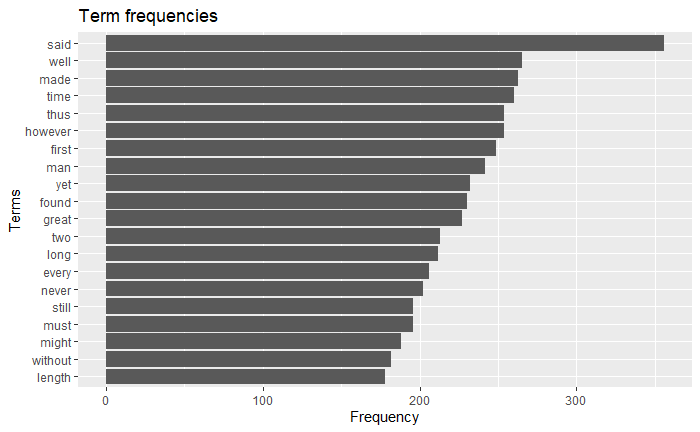

```r
high.fr=tail(sort(fr_EAP),n=20)
hfp.df=as.data.frame(sort(high.fr))
hfp.df$names <- rownames(hfp.df)

ggplot(hfp.df, aes(reorder(names,high.fr), high.fr)) +
  geom_bar(stat="identity") + coord_flip() +
  xlab("Terms") + ylab("Frequency") +
  ggtitle("Term frequencies")
```

Wordcloud

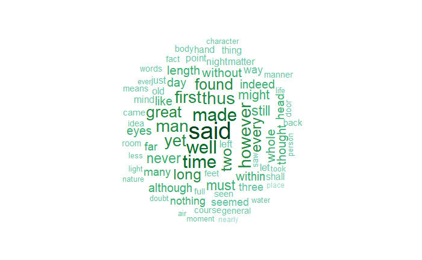

```r
word.cloud=wordcloud(words=names(fr_EAP), freq=fr_EAP, scale=c(2.5,.1),
                     min.freq = 100, random.order=F, color=pal)
```

Bigrams

```r
BigramTokenizer <- function(x) NGramTokenizer(x, Weka_control(min = 2, max = 2))

tdm_EAP.bigram = TermDocumentMatrix(corpus.EAP,
                                control = list (tokenize = BigramTokenizer))
```

Most common bigrams (barplot)

```r
freq = sort(rowSums(as.matrix(tdm_EAP.bigram)),decreasing = TRUE)
freq.df = data.frame(word=names(freq), freq=freq)
head(freq.df, 20)
```

|  | word | freq |
| --- | --- | --- |
| let us | let us | 50 |
| three four | three four | 23 |
| every thing | every thing | 22 |
| ha ha | ha ha | 22 |
| main compartment | main compartment | 21 |
| said dupin | said dupin | 21 |
| madame lalande | madame lalande | 20 |
| chess player | chess player | 18 |
| well known | well known | 18 |
| mr crab | mr crab | 17 |

[output cut: 10 more lines]

Most common bigrams (wordcloud)

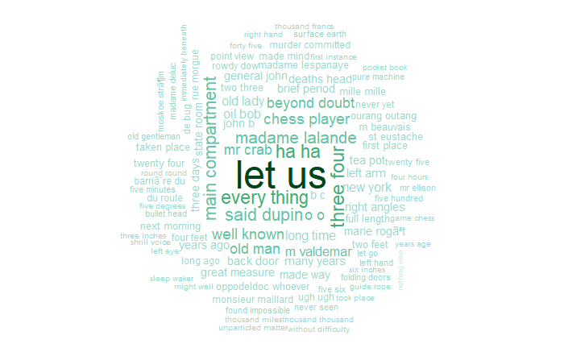

```r
wordcloud(freq.df$word,freq.df$freq,max.words=100,random.order = F, scale=c(3,.2), color=pal)
```

#### HPL

HP Lovecraft

```r
corpus.HPL = VCorpus(DataframeSource(df[df$author == "HPL",]))
corpus.HPL = tm_map(corpus.HPL, content_transformer(tolower))
corpus.HPL = tm_map(corpus.HPL, removeWords, c(stopwords(),new_stop_words))
corpus.HPL = tm_map(corpus.HPL, removePunctuation)
corpus.HPL = tm_map(corpus.HPL, removeNumbers)
corpus.HPL = tm_map(corpus.HPL, stripWhitespace)

tdm_HPL = TermDocumentMatrix(corpus.HPL)
fr_HPL = rowSums(as.matrix(tdm_HPL))
```

Barplot most common words

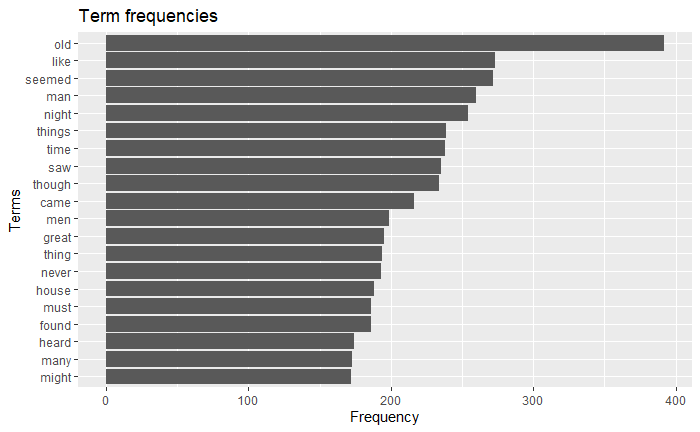

```r
high.fr=tail(sort(fr_HPL),n=20)
hfp.df=as.data.frame(sort(high.fr))
hfp.df$names <- rownames(hfp.df)

ggplot(hfp.df, aes(reorder(names,high.fr), high.fr)) +
  geom_bar(stat="identity") + coord_flip() +
  xlab("Terms") + ylab("Frequency") +
  ggtitle("Term frequencies")
```

Wordcloud

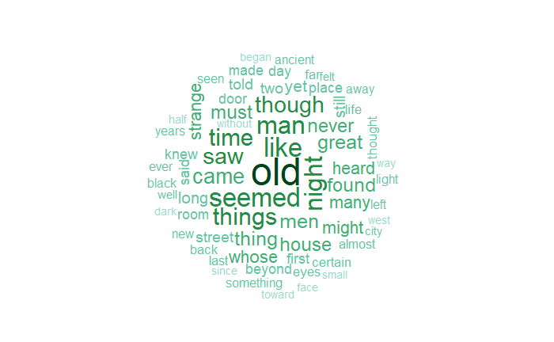

```r
word.cloud=wordcloud(words=names(fr_HPL), freq=fr_HPL, scale=c(3,.1),
                     min.freq = 100, random.order=F, color=pal)
```

Bigrams

```r
BigramTokenizer <- function(x) NGramTokenizer(x, Weka_control(min = 2, max = 2))

tdm_HPL.bigram = TermDocumentMatrix(corpus.HPL,
                                control = list (tokenize = BigramTokenizer))
```

Most common bigrams (barplot)

```r
freq = sort(rowSums(as.matrix(tdm_HPL.bigram)),decreasing = TRUE)
freq.df = data.frame(word=names(freq), freq=freq)
head(freq.df, 20)
```

|  | word | freq |
| --- | --- | --- |
| old man | old man | 53 |
| aout o | aout o | 19 |
| old woman | old woman | 19 |
| heh heh | heh heh | 17 |
| next day | next day | 16 |
| shunned house | shunned house | 16 |
| small hours | small hours | 14 |
| tempest mountain | tempest mountain | 14 |
| brown jenkin | brown jenkin | 13 |
| herbert west | herbert west | 13 |

[output cut: 10 more lines]

Most common bigrams (wordcloud)

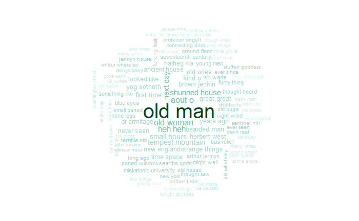

```r
wordcloud(freq.df$word,freq.df$freq,max.words=100,random.order = F, scale=c(2.5,.3), color=pal)
```

Old man and old woman are some of the most common bigrams, which seems interesting, in fact old man appears 53 times being the most common word by far.

#### MWS

```r
corpus.MWS = VCorpus(DataframeSource(df[df$author == "MWS",]))
corpus.MWS = tm_map(corpus.MWS, content_transformer(tolower))
corpus.MWS = tm_map(corpus.MWS, removeWords, c(stopwords(),new_stop_words))
corpus.MWS = tm_map(corpus.MWS, removePunctuation)
corpus.MWS = tm_map(corpus.MWS, removeNumbers)
corpus.MWS = tm_map(corpus.MWS, stripWhitespace)

tdm_HPL = TermDocumentMatrix(corpus.MWS)
fr_MWS = rowSums(as.matrix(tdm_MWS))
```

Barplot most common words

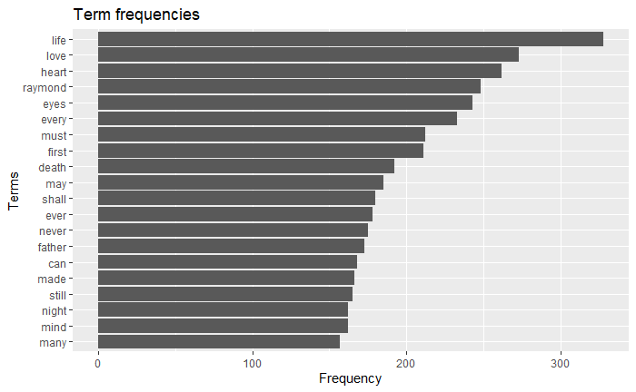

```r
high.fr=tail(sort(fr_MWS),n=20)
hfp.df=as.data.frame(sort(high.fr))
hfp.df$names <- rownames(hfp.df)

ggplot(hfp.df, aes(reorder(names,high.fr), high.fr)) +
  geom_bar(stat="identity") + coord_flip() +
  xlab("Terms") + ylab("Frequency") +
  ggtitle("Term frequencies")
```

Wordcloud

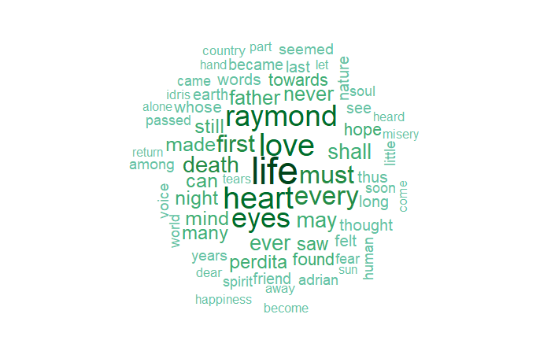

```r
word.cloud=wordcloud(words=names(fr_MWS), freq=fr_MWS, scale=c(3,.1),
                     min.freq = 100, random.order=F, color=pal)
```

Bigrams

```r
BigramTokenizer <- function(x) NGramTokenizer(x, Weka_control(min = 2, max = 2))

tdm_MWS.bigram = TermDocumentMatrix(corpus.MWS,
                                control = list (tokenize = BigramTokenizer))
```

Most common bigrams (barplot)

```r
freq = sort(rowSums(as.matrix(tdm_MWS.bigram)),decreasing = TRUE)
freq.df = data.frame(word=names(freq), freq=freq)
head(freq.df, 20)
```

|  | word | freq |
| --- | --- | --- |
| old man | old man | 29 |
| lord raymond | lord raymond | 27 |
| fellow creatures | fellow creatures | 22 |
| let us | let us | 16 |
| every day | every day | 14 |
| native country | native country | 14 |
| taken place | taken place | 14 |
| first time | first time | 12 |
| two years | two years | 12 |
| years age | years age | 12 |

[output cut: 10 more lines]

Most common bigrams (wordcloud)

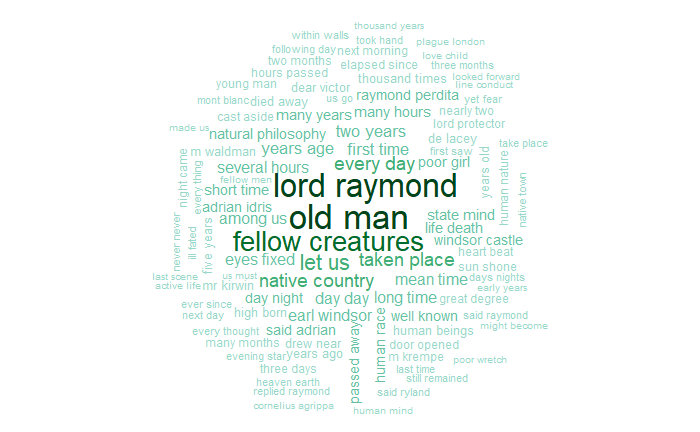

```r
wordcloud(freq.df$word,freq.df$freq,max.words=100,random.order = F, scale=c(2.2,.3), color=pal)
```

Total words and distinct words (how many distinct words an author uses) of each author

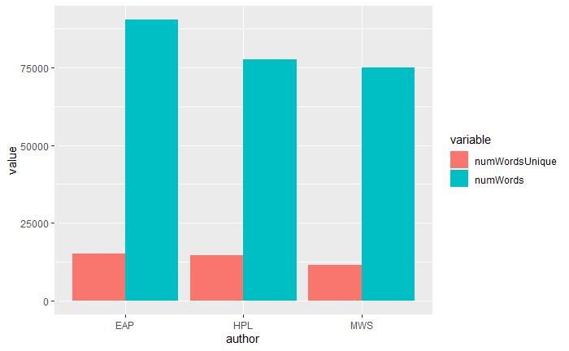

```r
df_numWords <- data.frame(numWordsUnique=c(length(fr_EAP), length(fr_HPL), length(fr_MWS)),
                          numWords = c(sum(unname(fr_EAP)), sum(unname(fr_HPL)), sum(unname(fr_MWS))),
                          author=c("EAP", "HPL", "MWS"))
df_numWords <- melt(df_numWords, id.vars = "author")

ggplot(df_numWords, aes(x=author, y=value, fill=variable)) +
    geom_bar(stat='identity', position='dodge')
```

```r
#ggplot(df_distincts, x=author, aes(y = numWords))+geom_bar()
```

## Topic modelling

Topic modeling is a technique for unsupervised classification of documents. This is similar to perform clustering on numerical data, finding natural groups of items with no previous knowledge of the data.

In this project we are going to use Latent Dirichlet allocation (LDA). For creating LDA models we are going to use the following function.

Original function from: https://www.kaggle.com/rtatman/nlp-in-r-topic-modelling#Setting-up-our-workspace

Also in the documentation/tutorial of Tidy: https://www.tidytextmining.com/topicmodeling.html#word-topic-probabilities

```r
# function to get & plot the most informative terms by a specificed number
# of topics, using LDA

top_terms_by_topic_LDA <- function(corpus,  plot = T, number_of_topics = 4) {

  # For this task we need a document term matrix instead of a term document matrix
  dtm <- DocumentTermMatrix(corpus)
  ui = unique(dtm$i)
  dtm = dtm[ui,]

  # preform LDA & get the words/topic
  lda_model <- LDA(dtm, k = number_of_topics, control = list(seed = 7))
  topics <- tidy(lda_model, matrix = "beta")

  # get the top ten terms for each topic
  top_terms <- topics  %>% # take the topics data frame and..
    group_by(topic) %>% # treat each topic as a different group
    top_n(10, beta) %>% # get the top 10 most informative words
    ungroup() %>% # ungroup
    arrange(topic, -beta) # arrange words in descending informativeness

  # if the user asks for a plot (TRUE by default)
  if(plot == T){
    # plot the top ten terms for each topic in order
    top_terms %>% # take the top terms
      mutate(term = reorder(term, beta)) %>% # sort terms by beta value
      ggplot(aes(term, beta, fill = factor(topic))) + # plot beta by theme
      geom_col(show.legend = FALSE) + # as a bar plot
      facet_wrap(~ topic, scales = "free") + # which each topic in a seperate plot
      labs(x = NULL, y = "Beta") + # no x label, change y label
      coord_flip() # turn bars sideways
  }else{
    # if the user does not request a plot
    # return de lda_model
    return (lda_model)
    # return a list of sorted terms instead
    #return(top_terms)
  }
}
```

we can try to get the top terms of each documents for 2 topics

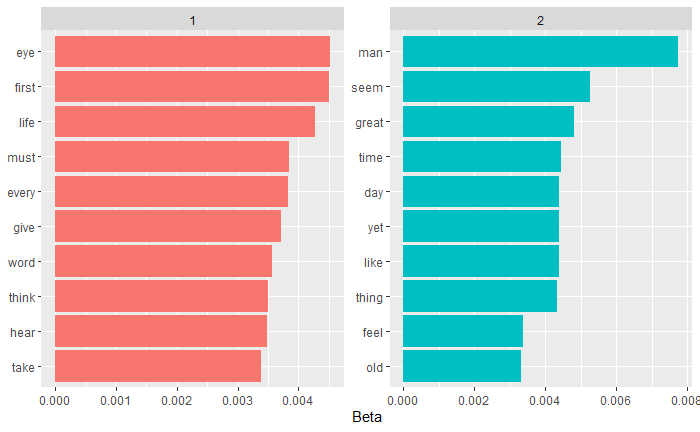

```r
top_terms_by_topic_LDA(corpus, plot = T, number_of_topics = 2)
```

we can try to get the top terms of each documents for 3 topics (hoping each topic belongs to 1 of the 3 authors)

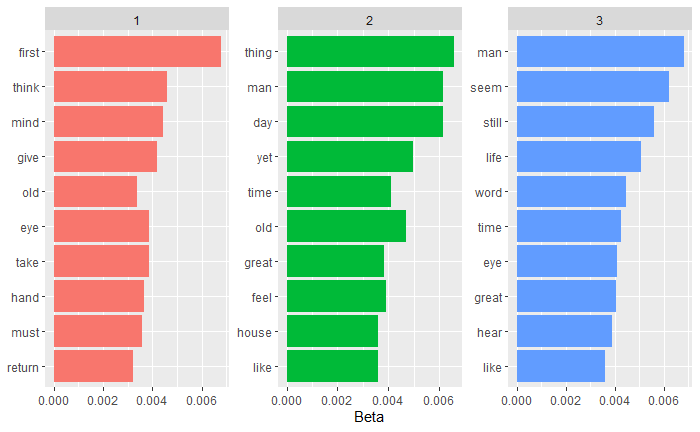

```r
top_terms_by_topic_LDA(corpus, plot = T, number_of_topics = 3)
```

```r
lda_model <- top_terms_by_topic_LDA(corpus, plot = F, number_of_topics = 3)
chapters_gamma <- tidy(lda_model, matrix = "gamma")

df_topics <- merge(df, chapters_gamma, by.x="doc_id", by.y="document")
df_topics$doc_id <- NULL
df_topics$text <- NULL
df_topics$gamma <- NULL
```

Authors distribution in topic 1

```r
df_topics_T1 = df_topics[df_topics$topic == 1,]
ggplot(df_topics_T1, aes(x=author, fill=author)) +
    geom_bar()
```

[output not shown]

Authors distribution in topic 2

```r
df_topics_T2 = df_topics[df_topics$topic == 2,]
ggplot(df_topics_T2, aes(x=author, fill=author)) +
    geom_bar()
```

[output not shown]

```r
df_topics_T3 = df_topics[df_topics$topic == 3,]
ggplot(df_topics_T3, aes(x=author, fill=author)) +
    geom_bar()
```

[output not shown]

Also we can try to run LDA with for each of the authors

For EAP

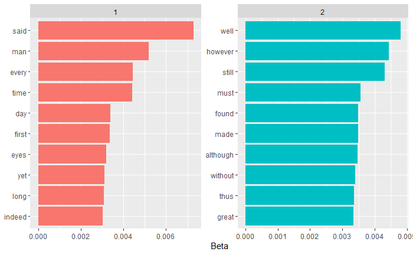

```r
top_terms_by_topic_LDA(corpus.EAP, plot = T, number_of_topics = 2)
```

HPL

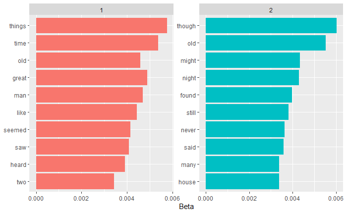

```r
top_terms_by_topic_LDA(corpus.HPL, plot = T, number_of_topics = 2)
```

MWS

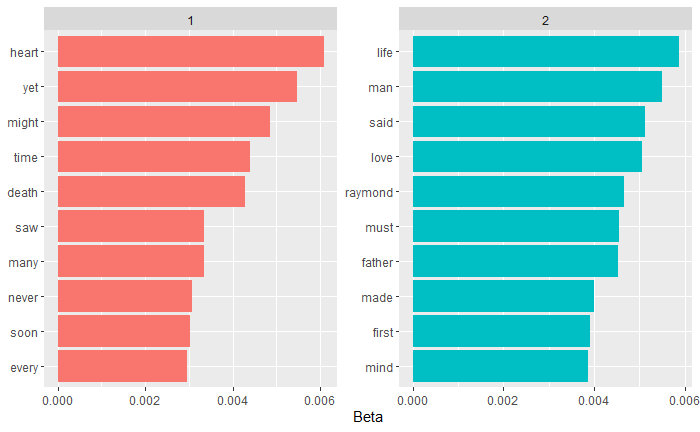

```r
top_terms_by_topic_LDA(corpus.MWS, plot = T, number_of_topics = 2)
```

As you can see the results are not very interpretable, also i do not know this authors and their work.

One possible solution could be using a document term matrix containing only nouns or adjective + nouns.